# 04_describe

Group 29: Helena Møller, Emma Christensen, Frederik Holmstrup, Casper Harreby & Laura Christiansen

# Descriptive analysis

## Loading Libraries

```r
library("tidyverse")
library("ggplot2")
library("dplyr")
library("readr")
library("here")
```

## Loading data

```r
data <- read_tsv(here("data/03_dat_aug.tsv"))
```

## Age distribution of study population

This section explores the age distribution of the study population:

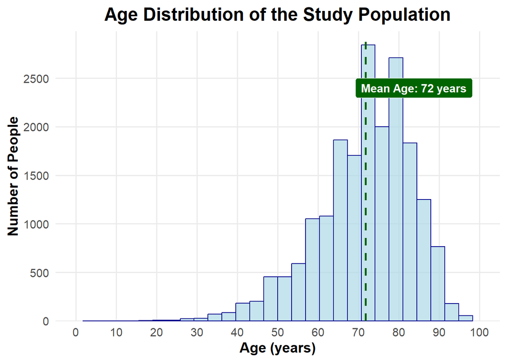

```r
# Calculate the mean age
mean_age <- mean(data$AGE, na.rm = TRUE)

# Excluding missing or negative ages
data <- data |>
  filter(!is.na(AGE) & AGE >= 0)

# Visualizing the age distribution
p1 <- ggplot(data, aes(x = AGE)) +
  geom_histogram(fill = "lightblue",
                 color = "darkblue",
                 bins = 30,
                 alpha = 0.7) +
  labs(
    title = "Age Distribution of the Study Population",
    x = "Age (years)",
    y = "Number of People"
  ) +
  theme_minimal(base_size = 14) +
  theme(
    plot.title = element_text(hjust = 0.5, face = "bold", size = 18),
    axis.title.x = element_text(face = "bold", size = 14),
    axis.title.y = element_text(face = "bold", size = 14),
    panel.grid.minor = element_blank()
  ) +
  scale_x_continuous(breaks = seq(0, 100, by = 10),
                     limits = c(0, 100)) +
  scale_y_continuous(expand = expansion(mult = c(0, 0.05)),
                     breaks = seq(0, 3000, by = 500)) +
  geom_segment(
    x = mean_age, xend = mean_age, y = 0, yend = 2900,
    color = "darkgreen", linetype = "dashed", size = 1.0
  ) +
  annotate(
    "label",
    x = mean_age + 12, y = 2400,
    label = paste("Mean Age:", round(mean_age, 0), "years"),
    color = "white", fill = "darkgreen",
    fontface = "bold", size = 4,
    label.padding = unit(0.4, "lines")
    # Mean age shown in a text box with padding
  )
# Display the plot
print(p1)
```

From the histogram distributed by age, it can be seen that the mean age of the study population is 72 years.

## Age distribution of stroke subtypes (STYPE)

The stroke subtypes (STYPE) are here distributed by age and visualized with boxplots. Here’s a brief description of the different subtypes:

- **LACS (Lacunar Stroke Syndrome)**

  Blockage of small penetrating arteries in deep brain structures, such as the basal ganglia, thalamus, or internal capsule. The prognosis is genereally better than other subtypes; smaller infarct size, where infarct size refers to the portion of the brain that has suffered irreversible damage from a stroke due to insufficient oxygen and nutrients.
- **PACS (Partial Anterior Circulation Syndrome)**

  Partial occlusion in the anterior cerebral circulation, typically affecting the middle cerebral artery (MCA) or anterior cerebral artery (ACA). The prognosis is moderate; larger infarct than LACS, but less severe than e.g TACS.
- **POCS (Posterior Circulation Syndrome)**

  Infarction in the posterior cerebral circulation, affecting the brainstem, cerebellum, or occipital lobes. The prognosis is variable, depending on location and size of the infarction.
- **TACS (Total Anterior Circulation Syndrome)**

  Complete occlusion of the anterior cerebral circulation, typically affecting the middle cerebral artery (MCA) or internal carotid artery (ICA). The prognosis is poor; associated with large infarcts, severe disability, and high mortality rates.
- **OTH** refers to other types of strokes.

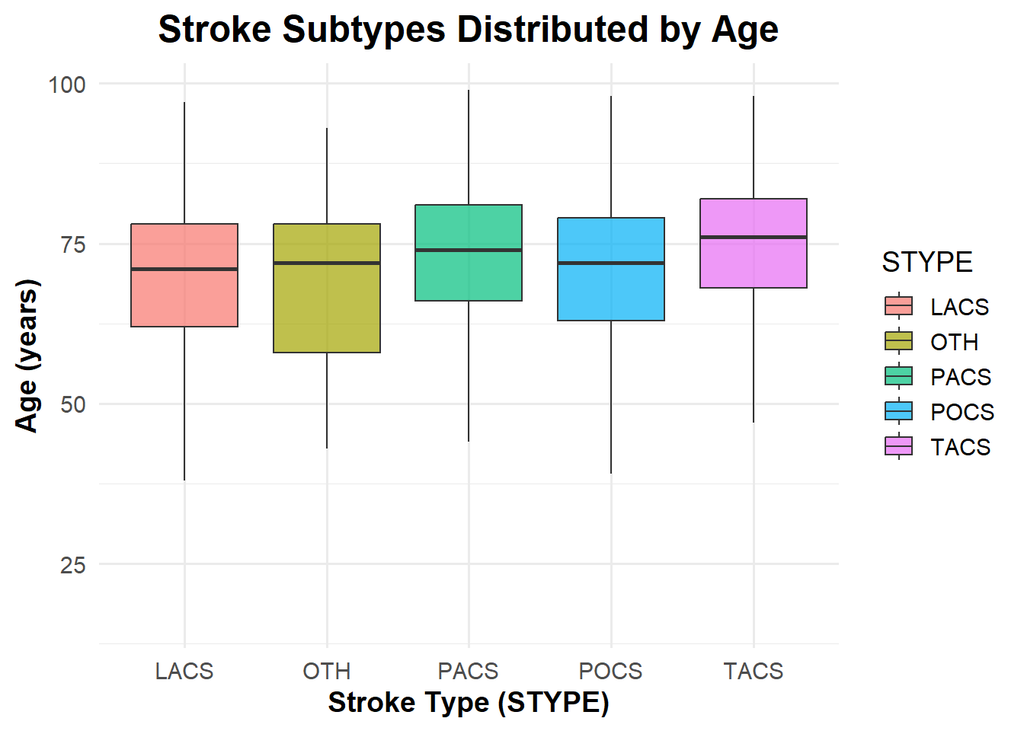

```r
p2 <- data |>
  ggplot(aes(x = STYPE, y = AGE, fill = STYPE)) +
  geom_boxplot(alpha = 0.7, outlier.shape = NA) + # Boxplot without outlier points
  labs(
    title = "Stroke Subtypes Distributed by Age",
    x = "Stroke Type (STYPE)",
    y = "Age (years)"
  ) +
  theme_minimal(base_size = 14) +
  theme(
    plot.title = element_text(hjust = 0.5, face = "bold", size = 18),
    axis.title.x = element_text(face = "bold", size = 14),
    axis.title.y = element_text(face = "bold", size = 14),
    legend.position = "right"
  )

# Display the plot
print(p2)
```

```r
STYPE_median <- data |>
  group_by(STYPE) |>
  summarize(Median_AGE = round(median(AGE, na.rm = TRUE), 0))

print(STYPE_median)
```

[output not shown]

# Data visualization

```r
# Summarize and count patients by data group
data_summary <- data |>
  group_by(data_group) |>
  count(name = "patient_count")

print(data_summary)
```

[output not shown]

## Predicted probability of death by gender at 6 months

This section visualizes the predicted probability of death at six months (EXPD6) by gender. A boxplot is used to compare probabilities.

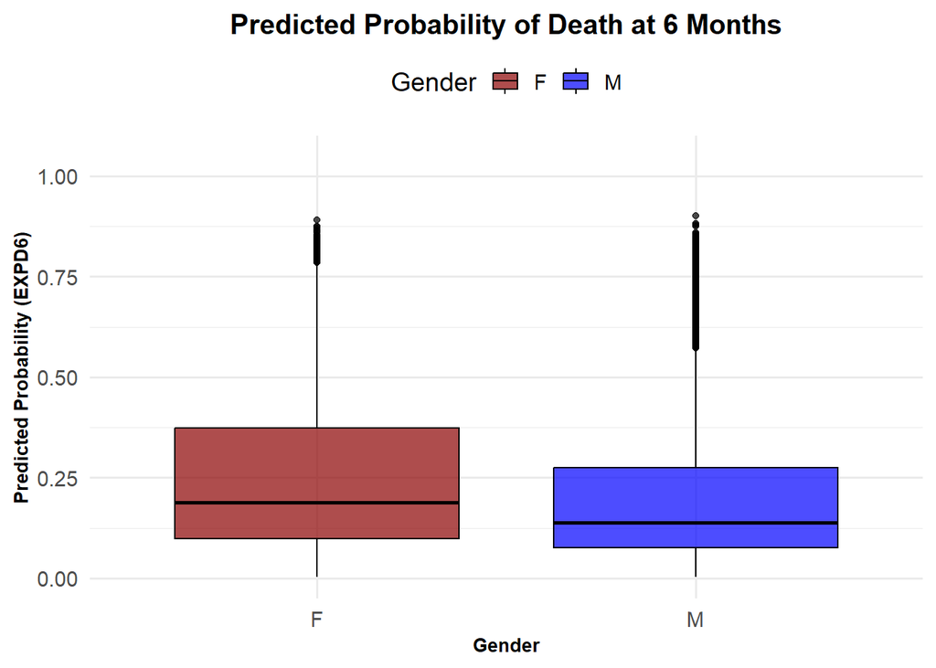

```r
# Create boxplot for predicted probability of death by gender
p3 <- data |>
  ggplot(aes(x = SEX, y = EXPD6, fill = SEX)) +
  geom_boxplot(alpha = 0.7, color = "black") +
  scale_fill_manual(values = c("darkred", "blue")) +
  labs(
    title = "Predicted Probability of Death at 6 Months",
    x = "Gender",
    y = "Predicted Probability (EXPD6)",
    fill = "Gender"
  ) +
  theme_minimal(base_size = 14) +
  theme(
    plot.title = element_text(hjust = 0.5, face = "bold", size = 15),
    axis.title.x = element_text(face = "bold", size = 10),
    axis.title.y = element_text(face = "bold", size = 10),
    legend.position = "top"
  ) +
  scale_y_continuous(
    limits = c(0, 1),
    expand = expansion(mult = c(0.05, 0.1))
  )

# Display the plot
print(p3)
```

## Comparison of median of EXPD6 by gender

```r
#Show median EXPD6 by gender

median_table <- data |>
  group_by(SEX) |>
  summarize(Median_EXPD6 = median(EXPD6, na.rm = TRUE))

print(median_table)
```

[output not shown]

## Save the results

```r
# Save the plots as PNG files

ggsave(here("results/04_description_plot_1.png"), plot = p1, width = 8, height = 4, dpi = 300, bg = "white")
ggsave(here("results/04_description_plot_2.png"), plot = p2, width = 8, height = 4, dpi = 300, bg = "white")

ggsave(here("results/04_description_plot_3.png"), plot = p3, width = 8, height = 4, dpi = 300, bg = "white")
```